# PracticalMachineLearning

Sylas

16 July 2017

# PRACTICAL MACHINE LEARNING

#### Loading the data and creating the pairs plot for the classifier to be used to go through the visual representation of the classifier i am going to use.To predict the classes of output from the human recognition data. Th class value reprsent, class-A throws elbows to the front,Class-B lifting the dumbbell only halfway (Class C), lowering the dumbbell only halfway (Class D) and throwing the hips to the front (Class E).To predict the class value identified the releveant classifier and created the formula to pass in the random forest algorithm.

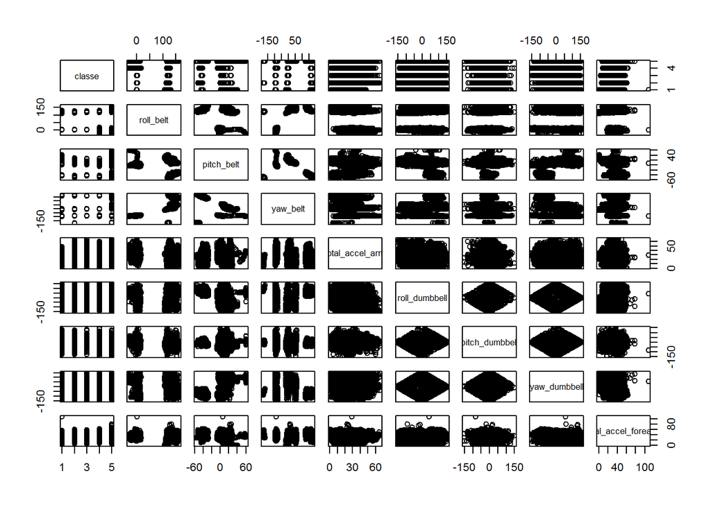

```r
setwd("C:/Coursera/Practical Machine Learning")
train <- read.csv("pml-training.csv",header=T,stringsAsFactors=T, sep=",")
test <- read.csv("pml-testing.csv",header=T,stringsAsFactors=T, sep=",")
pairs(classe ~ roll_belt+pitch_belt+yaw_belt+total_accel_arm+roll_dumbbell+pitch_dumbbell+yaw_dumbbell+total_accel_forearm,data=train)
```

```r
classif <- formula(classe  ~ roll_belt+pitch_belt+yaw_belt+total_accel_arm+roll_dumbbell+pitch_dumbbell+yaw_dumbbell+roll_arm+pitch_arm+magnet_dumbbell_x+magnet_dumbbell_y+magnet_dumbbell_z+roll_forearm+pitch_forearm+yaw_forearm+total_accel_forearm)
model <-randomForest(classif,data=train,importance=TRUE)
importance(model)
```

```
##                            A        B        C        D        E
## roll_belt           64.07883 86.72269 77.26838 67.53171 91.72799
## pitch_belt          44.35566 85.58013 59.08506 58.37649 50.85785
## yaw_belt            59.11044 80.95106 68.28986 83.83051 42.85351
## total_accel_arm     29.09290 58.14365 54.46384 51.37601 43.91228
## roll_dumbbell       38.00773 51.44390 50.71518 47.31311 50.19364
## pitch_dumbbell      20.90722 33.04667 29.38540 24.22383 32.93591
## yaw_dumbbell        26.41845 42.88620 42.22505 39.07840 47.52779
## roll_arm            37.23341 52.98026 44.71333 46.93594 32.77933
## pitch_arm           26.58540 47.18874 38.84594 36.93928 33.00157
## magnet_dumbbell_x   34.67960 42.08974 47.05366 37.99652 38.57981
## magnet_dumbbell_y   47.73881 55.61175 66.19454 54.21533 46.61181
## magnet_dumbbell_z   63.36482 58.92875 85.46381 59.59485 59.27748
## roll_forearm        39.50857 36.79063 47.18432 36.39321 34.93455
## pitch_forearm       51.53143 58.48715 58.34626 79.93697 62.82051
## yaw_forearm         30.97842 38.07080 40.94455 39.94996 42.95349
## total_accel_forearm 32.74722 39.92456 42.76434 36.77706 31.20160
##                     MeanDecreaseAccuracy MeanDecreaseGini
## roll_belt                      107.15792        2504.2898
## pitch_belt                      80.43506        1416.4781
## yaw_belt                        91.80643        1774.8842
## total_accel_arm                 66.68703         377.3855
## roll_dumbbell                   56.33018         785.4184
## pitch_dumbbell                  32.13653         396.7957
## yaw_dumbbell                    49.28309         582.0929
## roll_arm                        60.23563         724.6188
## pitch_arm                       44.57649         382.4203
## magnet_dumbbell_x               43.56339         914.8187
## magnet_dumbbell_y               64.59559        1140.4434
## magnet_dumbbell_z               79.89178        1311.2480
## roll_forearm                    42.38086        1076.0780
## pitch_forearm                   76.27573        1393.2218
## yaw_forearm                     55.62656         443.3965
## total_accel_forearm             50.84707         289.2460
```

```r
print(model)
```

```
##
## Call:
##  randomForest(formula = classif, data = train, importance = TRUE)
##                Type of random forest: classification
##                      Number of trees: 500
## No. of variables tried at each split: 4
##
##         OOB estimate of  error rate: 0.52%
## Confusion matrix:
##      A    B    C    D    E class.error
## A 5574    6    0    0    0 0.001075269
## B   16 3747   32    2    0 0.013168291
## C    0    9 3405    8    0 0.004967855
## D    0    1   16 3197    2 0.005907960
## E    0    3    3    5 3596 0.003049626
```

```r
test_predict <- predict (model,test)
```

## CROSS VALIDATION ALGORITHM

#### Used the 3 cross validation to verify the out of sample error and applied the predicted value to the test data.

```r
first_seed <- 1234
accuracies <-c()
for (i in 1:3){
       set.seed(first_seed)
       first_seed <- first_seed+1
       trainIndex <- createDataPartition(y=train$classe, p=0.75, list=FALSE)
       trainingSet<- train[trainIndex,]
       testingSet<- train[-trainIndex,]
       modelFit <- randomForest(classif, data = trainingSet,importance=TRUE)
       prediction <- predict(modelFit, testingSet)
       testingSet$rightPred <- prediction == testingSet$classe
       t<-table(prediction, testingSet$classe)
       print(modelFit)
       accuracy <- sum(testingSet$rightPred)/nrow(testingSet)
       accuracies <- c(accuracies,accuracy)
       print(accuracy)
}
```

```
##
## Call:
##  randomForest(formula = classif, data = trainingSet, importance = TRUE)
##                Type of random forest: classification
##                      Number of trees: 500
## No. of variables tried at each split: 4
##
##         OOB estimate of  error rate: 0.73%
## Confusion matrix:
##      A    B    C    D    E class.error
## A 4176    7    0    0    2 0.002150538
## B   14 2805   24    5    0 0.015098315
## C    0    9 2551    7    0 0.006232957
## D    0    0   18 2391    3 0.008706468
## E    0    4    6    9 2687 0.007021434
## [1] 0.9946982
##
## Call:
##  randomForest(formula = classif, data = trainingSet, importance = TRUE)
##                Type of random forest: classification
##                      Number of trees: 500
## No. of variables tried at each split: 4
##
##         OOB estimate of  error rate: 0.77%
## Confusion matrix:
##      A    B    C    D    E class.error
## A 4178    6    0    1    0 0.001672640
## B   15 2799   32    2    0 0.017205056
## C    0   12 2547    8    0 0.007791196
## D    0    0   21 2389    2 0.009535655
## E    0    4    4    6 2692 0.005173688
## [1] 0.9908238
##
## Call:
##  randomForest(formula = classif, data = trainingSet, importance = TRUE)
##                Type of random forest: classification
##                      Number of trees: 500
## No. of variables tried at each split: 4
##
##         OOB estimate of  error rate: 0.79%
## Confusion matrix:
##      A    B    C    D    E class.error
## A 4172   11    0    1    1 0.003106332
## B   14 2802   32    0    0 0.016151685
## C    0   11 2543   13    0 0.009349435
## D    0    0   21 2388    3 0.009950249
## E    0    2    2    5 2697 0.003325942
## [1] 0.9924551
```

```r
predict_test <- predict (modelFit,test)
predict_test
```

```
##  1  2  3  4  5  6  7  8  9 10 11 12 13 14 15 16 17 18 19 20
##  B  A  B  A  A  E  D  B  A  A  B  C  B  A  E  E  A  B  B  B
## Levels: A B C D E
```

#### In the above method of cross validation sample the out of bag error is in the range of 0.75 and it is very close to the full model OOB error, also the accuracy rate comingout of the cross validation method random forest application is in the good mark.This model is not overfitted it produce the accurate results in the test data prediction.